# ABOUT DATA

The data has been collected in İstanbul via an online form. It is aimed to examine the depression scores of married people and the influence of demographic factors.  
Demographic Questions and Beck Depression Inventory is used to collect data. Total Score of Scale must be calculated by the sum of items B1-B21. Codes reflecting the categories of demographic questions are as below.

Gender: 1-Female, 2-Male;

Education: 1-Primary, 2-High School, 3-Bachelor, 4-Msc or PhD;

Working Status: 1-Employed, 2-Unemployed;

Marriage Style : 1-Arranged Marriage, 2-Flirt Marriage;

Status of Having a Child: 1-Yes, 2-No

# Beck's Depression Inventory

The Beck Depression Inventory (BDI), created by Aaron T. Beck, is a 21-question multiple-choice self-report inventory, one of the most widely used psychometric tests for measuring the severity of depression. Its development marked a shift among mental health professionals, who had until then, viewed depression from a psychodynamic perspective, instead of it being rooted in the patient's own thoughts.

Each of the 21 questions are 4 optioned questions having score from 0 to 3. Minimum score being 0 and maximum being 63.The degree of depression is directly proportional to the BDI score

Some of the questions are :

1. - 0 I do not feel sad
   - 1 I feel sad
   - 2 I am sad all the time and I can't snap out of it.
   - 3 I am so sad and unhappy that I can't stand it.
2. - 0 I am not particularly discouraged about the future.
   - 1 I feel discouraged about the future.
   - 2 I feel I have nothing to look forward to.
   - 3 I feel the future is hopeless and that things cannot improve.

For more details on the questions [visit here](https://www.ismanet.org/doctoryourspirit/pdfs/Beck-Depression-Inventory-BDI.pdf)

## BDI Score

Based on the BDI score, the patient is categorised as follows :

- Below 10 : These ups and downs are considered normal
- 11-16 : Mild mood disturbance
- 17-20 : Borderline clinical depression
- 21-30 : Moderate depression
- 31-40 : Severe depression
- Over 40 : Extreme depression

## Importing Required Packages

```python
import pandas as pd
import numpy as np
import matplotlib.pyplot as plt
import seaborn as sns
```

## Loading Data

```python
df = pd.read_csv('Dataset 1.csv')
df.head()
```

|  | No | Gender | Education | Working Status | Marriage Style | Status of Having a Child | B1 | B2 | B3 | B4 | ... | B12 | B13 | B14 | B15 | B16 | B17 | B18 | B19 | B20 | B21 |
| --- | --- | --- | --- | --- | --- | --- | --- | --- | --- | --- | --- | --- | --- | --- | --- | --- | --- | --- | --- | --- | --- |
| 0 | 345 | 2 | 4 | 2 | 2 | 2 | 3 | 3 | 3 | 3 | ... | 3 | 3 | 3 | 3 | 3 | 3 | 3 | 3 | 3 | 3 |
| 1 | 73 | 2 | 3 | 2 | 2 | 1 | 1 | 1 | 1 | 1 | ... | 1 | 0 | 1 | 1 | 0 | 1 | 0 | 0 | 0 | 0 |
| 2 | 107 | 2 | 4 | 2 | 2 | 1 | 0 | 0 | 0 | 1 | ... | 1 | 0 | 1 | 0 | 0 | 1 | 0 | 0 | 0 | 1 |
| 3 | 131 | 2 | 4 | 2 | 2 | 1 | 0 | 1 | 0 | 1 | ... | 0 | 0 | 0 | 0 | 3 | 0 | 0 | 0 | 0 | 0 |
| 4 | 4 | 2 | 4 | 2 | 1 | 1 | 0 | 0 | 0 | 0 | ... | 0 | 0 | 0 | 0 | 0 | 0 | 0 | 0 | 0 | 0 |

5 rows × 27 columns

## Data Manipulation

*We'll need to make some small changes to make better visualizations, make working with the data easier, and make the data more meaningful.*

```python
df['Gender'] = df['Gender'].replace(1, 'Female')
df['Gender'] = df['Gender'].replace(2, 'Male')
```

```python
df.head()
```

|  | No | Gender | Education | Working Status | Marriage Style | Status of Having a Child | B1 | B2 | B3 | B4 | ... | B12 | B13 | B14 | B15 | B16 | B17 | B18 | B19 | B20 | B21 |
| --- | --- | --- | --- | --- | --- | --- | --- | --- | --- | --- | --- | --- | --- | --- | --- | --- | --- | --- | --- | --- | --- |
| 0 | 345 | Male | 4 | 2 | 2 | 2 | 3 | 3 | 3 | 3 | ... | 3 | 3 | 3 | 3 | 3 | 3 | 3 | 3 | 3 | 3 |
| 1 | 73 | Male | 3 | 2 | 2 | 1 | 1 | 1 | 1 | 1 | ... | 1 | 0 | 1 | 1 | 0 | 1 | 0 | 0 | 0 | 0 |
| 2 | 107 | Male | 4 | 2 | 2 | 1 | 0 | 0 | 0 | 1 | ... | 1 | 0 | 1 | 0 | 0 | 1 | 0 | 0 | 0 | 1 |
| 3 | 131 | Male | 4 | 2 | 2 | 1 | 0 | 1 | 0 | 1 | ... | 0 | 0 | 0 | 0 | 3 | 0 | 0 | 0 | 0 | 0 |
| 4 | 4 | Male | 4 | 2 | 1 | 1 | 0 | 0 | 0 | 0 | ... | 0 | 0 | 0 | 0 | 0 | 0 | 0 | 0 | 0 | 0 |

5 rows × 27 columns

```python
df['Education'] = df['Education'].replace(1, 'Primary')
df['Education'] = df['Education'].replace(2, 'High School')
df['Education'] = df['Education'].replace(3, 'Bachelor')
df['Education'] = df['Education'].replace(4, 'Msc or PhD')
```

```python
df.head()
```

|  | No | Gender | Education | Working Status | Marriage Style | Status of Having a Child | B1 | B2 | B3 | B4 | ... | B12 | B13 | B14 | B15 | B16 | B17 | B18 | B19 | B20 | B21 |
| --- | --- | --- | --- | --- | --- | --- | --- | --- | --- | --- | --- | --- | --- | --- | --- | --- | --- | --- | --- | --- | --- |
| 0 | 345 | Male | Msc or PhD | 2 | 2 | 2 | 3 | 3 | 3 | 3 | ... | 3 | 3 | 3 | 3 | 3 | 3 | 3 | 3 | 3 | 3 |
| 1 | 73 | Male | Bachelor | 2 | 2 | 1 | 1 | 1 | 1 | 1 | ... | 1 | 0 | 1 | 1 | 0 | 1 | 0 | 0 | 0 | 0 |
| 2 | 107 | Male | Msc or PhD | 2 | 2 | 1 | 0 | 0 | 0 | 1 | ... | 1 | 0 | 1 | 0 | 0 | 1 | 0 | 0 | 0 | 1 |
| 3 | 131 | Male | Msc or PhD | 2 | 2 | 1 | 0 | 1 | 0 | 1 | ... | 0 | 0 | 0 | 0 | 3 | 0 | 0 | 0 | 0 | 0 |
| 4 | 4 | Male | Msc or PhD | 2 | 1 | 1 | 0 | 0 | 0 | 0 | ... | 0 | 0 | 0 | 0 | 0 | 0 | 0 | 0 | 0 | 0 |

5 rows × 27 columns

```python
df['Working Status'] = df['Working Status'].replace(1, 'Employed')
df['Working Status'] = df['Working Status'].replace(2, 'Unemployed')
```

```python
df.head()
```

|  | No | Gender | Education | Working Status | Marriage Style | Status of Having a Child | B1 | B2 | B3 | B4 | ... | B12 | B13 | B14 | B15 | B16 | B17 | B18 | B19 | B20 | B21 |
| --- | --- | --- | --- | --- | --- | --- | --- | --- | --- | --- | --- | --- | --- | --- | --- | --- | --- | --- | --- | --- | --- |
| 0 | 345 | Male | Msc or PhD | Unemployed | 2 | 2 | 3 | 3 | 3 | 3 | ... | 3 | 3 | 3 | 3 | 3 | 3 | 3 | 3 | 3 | 3 |
| 1 | 73 | Male | Bachelor | Unemployed | 2 | 1 | 1 | 1 | 1 | 1 | ... | 1 | 0 | 1 | 1 | 0 | 1 | 0 | 0 | 0 | 0 |
| 2 | 107 | Male | Msc or PhD | Unemployed | 2 | 1 | 0 | 0 | 0 | 1 | ... | 1 | 0 | 1 | 0 | 0 | 1 | 0 | 0 | 0 | 1 |
| 3 | 131 | Male | Msc or PhD | Unemployed | 2 | 1 | 0 | 1 | 0 | 1 | ... | 0 | 0 | 0 | 0 | 3 | 0 | 0 | 0 | 0 | 0 |
| 4 | 4 | Male | Msc or PhD | Unemployed | 1 | 1 | 0 | 0 | 0 | 0 | ... | 0 | 0 | 0 | 0 | 0 | 0 | 0 | 0 | 0 | 0 |

5 rows × 27 columns

```python
df['Marriage Style'] = df['Marriage Style'].replace(1, 'Arranged Marriage')
df['Marriage Style'] = df['Marriage Style'].replace(2, 'Flirt Marriage')
```

```python
df.head()
```

|  | No | Gender | Education | Working Status | Marriage Style | Status of Having a Child | B1 | B2 | B3 | B4 | ... | B12 | B13 | B14 | B15 | B16 | B17 | B18 | B19 | B20 | B21 |
| --- | --- | --- | --- | --- | --- | --- | --- | --- | --- | --- | --- | --- | --- | --- | --- | --- | --- | --- | --- | --- | --- |
| 0 | 345 | Male | Msc or PhD | Unemployed | Flirt Marriage | 2 | 3 | 3 | 3 | 3 | ... | 3 | 3 | 3 | 3 | 3 | 3 | 3 | 3 | 3 | 3 |
| 1 | 73 | Male | Bachelor | Unemployed | Flirt Marriage | 1 | 1 | 1 | 1 | 1 | ... | 1 | 0 | 1 | 1 | 0 | 1 | 0 | 0 | 0 | 0 |
| 2 | 107 | Male | Msc or PhD | Unemployed | Flirt Marriage | 1 | 0 | 0 | 0 | 1 | ... | 1 | 0 | 1 | 0 | 0 | 1 | 0 | 0 | 0 | 1 |
| 3 | 131 | Male | Msc or PhD | Unemployed | Flirt Marriage | 1 | 0 | 1 | 0 | 1 | ... | 0 | 0 | 0 | 0 | 3 | 0 | 0 | 0 | 0 | 0 |
| 4 | 4 | Male | Msc or PhD | Unemployed | Arranged Marriage | 1 | 0 | 0 | 0 | 0 | ... | 0 | 0 | 0 | 0 | 0 | 0 | 0 | 0 | 0 | 0 |

5 rows × 27 columns

```python
df['Status of Having a Child'] = df['Status of Having a Child'].replace(1, 'Yes')
df['Status of Having a Child'] = df['Status of Having a Child'].replace(2, 'No')
df.head()
```

|  | No | Gender | Education | Working Status | Marriage Style | Status of Having a Child | B1 | B2 | B3 | B4 | ... | B12 | B13 | B14 | B15 | B16 | B17 | B18 | B19 | B20 | B21 |
| --- | --- | --- | --- | --- | --- | --- | --- | --- | --- | --- | --- | --- | --- | --- | --- | --- | --- | --- | --- | --- | --- |
| 0 | 345 | Male | Msc or PhD | Unemployed | Flirt Marriage | No | 3 | 3 | 3 | 3 | ... | 3 | 3 | 3 | 3 | 3 | 3 | 3 | 3 | 3 | 3 |
| 1 | 73 | Male | Bachelor | Unemployed | Flirt Marriage | Yes | 1 | 1 | 1 | 1 | ... | 1 | 0 | 1 | 1 | 0 | 1 | 0 | 0 | 0 | 0 |
| 2 | 107 | Male | Msc or PhD | Unemployed | Flirt Marriage | Yes | 0 | 0 | 0 | 1 | ... | 1 | 0 | 1 | 0 | 0 | 1 | 0 | 0 | 0 | 1 |
| 3 | 131 | Male | Msc or PhD | Unemployed | Flirt Marriage | Yes | 0 | 1 | 0 | 1 | ... | 0 | 0 | 0 | 0 | 3 | 0 | 0 | 0 | 0 | 0 |
| 4 | 4 | Male | Msc or PhD | Unemployed | Arranged Marriage | Yes | 0 | 0 | 0 | 0 | ... | 0 | 0 | 0 | 0 | 0 | 0 | 0 | 0 | 0 | 0 |

5 rows × 27 columns

## Data Cleaning

```python
df.isnull().sum()
```

```
No                          0
Gender                      0
Education                   0
Working Status              0
Marriage Style              0
Status of Having a Child    0
B1                          0
B2                          0
B3                          0
B4                          0
B5                          0
B6                          0
B7                          0
B8                          0
B9                          0
B10                         0
B11                         0
B12                         0
B13                         0
B14                         0
B15                         0
B16                         0
B17                         0
B18                         0
B19                         0
B20                         0
B21                         0
dtype: int64
```

*We see that there are no null values in the data.*

```python
df.drop(columns=['No'])
```

|  | Gender | Education | Working Status | Marriage Style | Status of Having a Child | B1 | B2 | B3 | B4 | B5 | ... | B12 | B13 | B14 | B15 | B16 | B17 | B18 | B19 | B20 | B21 |
| --- | --- | --- | --- | --- | --- | --- | --- | --- | --- | --- | --- | --- | --- | --- | --- | --- | --- | --- | --- | --- | --- |
| 0 | Male | Msc or PhD | Unemployed | Flirt Marriage | No | 3 | 3 | 3 | 3 | 3 | ... | 3 | 3 | 3 | 3 | 3 | 3 | 3 | 3 | 3 | 3 |
| 1 | Male | Bachelor | Unemployed | Flirt Marriage | Yes | 1 | 1 | 1 | 1 | 1 | ... | 1 | 0 | 1 | 1 | 0 | 1 | 0 | 0 | 0 | 0 |
| 2 | Male | Msc or PhD | Unemployed | Flirt Marriage | Yes | 0 | 0 | 0 | 1 | 1 | ... | 1 | 0 | 1 | 0 | 0 | 1 | 0 | 0 | 0 | 1 |
| 3 | Male | Msc or PhD | Unemployed | Flirt Marriage | Yes | 0 | 1 | 0 | 1 | 1 | ... | 0 | 0 | 0 | 0 | 3 | 0 | 0 | 0 | 0 | 0 |
| 4 | Male | Msc or PhD | Unemployed | Arranged Marriage | Yes | 0 | 0 | 0 | 0 | 1 | ... | 0 | 0 | 0 | 0 | 0 | 0 | 0 | 0 | 0 | 0 |
| ... | ... | ... | ... | ... | ... | ... | ... | ... | ... | ... | ... | ... | ... | ... | ... | ... | ... | ... | ... | ... | ... |
| 428 | Female | High School | Employed | Arranged Marriage | Yes | 0 | 0 | 0 | 0 | 0 | ... | 0 | 0 | 0 | 0 | 0 | 0 | 0 | 0 | 0 | 0 |
| 429 | Female | High School | Employed | Arranged Marriage | Yes | 0 | 0 | 0 | 1 | 0 | ... | 1 | 0 | 1 | 1 | 0 | 1 | 0 | 0 | 1 | 2 |
| 430 | Female | Primary | Employed | Arranged Marriage | Yes | 0 | 0 | 0 | 0 | 0 | ... | 1 | 2 | 1 | 1 | 1 | 2 | 0 | 0 | 2 | 1 |
| 431 | Female | Bachelor | Employed | Flirt Marriage | Yes | 0 | 0 | 0 | 0 | 0 | ... | 1 | 0 | 0 | 0 | 0 | 0 | 0 | 0 | 0 | 0 |
| 432 | Female | Primary | Employed | Flirt Marriage | Yes | 0 | 0 | 0 | 0 | 0 | ... | 0 | 0 | 0 | 0 | 0 | 0 | 0 | 0 | 0 | 0 |

433 rows × 26 columns

*The numbering order is data we don't need. And we have to get rid of it.*

## Basic Statistics

*Let's see how many columns and rows there are.*

```python
df.shape
```

```
(433, 27)
```

*Let's look at some basic statistics like mean, median, standart deviation and etc. about the data.*

```python
df.describe()
```

|  | No | B1 | B2 | B3 | B4 | B5 | B6 | B7 | B8 | B9 | ... | B12 | B13 | B14 | B15 | B16 | B17 | B18 | B19 | B20 | B21 |
| --- | --- | --- | --- | --- | --- | --- | --- | --- | --- | --- | --- | --- | --- | --- | --- | --- | --- | --- | --- | --- | --- |
| count | 433.000000 | 433.000000 | 433.000000 | 433.000000 | 433.000000 | 433.000000 | 433.000000 | 433.000000 | 433.000000 | 433.000000 | ... | 433.000000 | 433.000000 | 433.000000 | 433.000000 | 433.000000 | 433.000000 | 433.000000 | 433.000000 | 433.000000 | 433.000000 |
| mean | 216.274827 | 0.397229 | 0.392610 | 0.450346 | 0.612009 | 0.678984 | 0.568129 | 0.503464 | 0.515012 | 0.163972 | ... | 0.665127 | 0.579677 | 0.418014 | 0.528868 | 0.551963 | 0.732102 | 0.244804 | 0.224018 | 0.429561 | 0.475751 |
| std | 125.181852 | 0.747955 | 0.741083 | 0.834974 | 0.668085 | 0.620593 | 0.847436 | 0.642342 | 0.684065 | 0.474727 | ... | 0.776452 | 0.759966 | 0.655001 | 0.790407 | 0.731375 | 0.721566 | 0.577452 | 0.625963 | 0.694058 | 0.742237 |
| min | 1.000000 | 0.000000 | 0.000000 | 0.000000 | 0.000000 | 0.000000 | 0.000000 | 0.000000 | 0.000000 | 0.000000 | ... | 0.000000 | 0.000000 | 0.000000 | 0.000000 | 0.000000 | 0.000000 | 0.000000 | 0.000000 | 0.000000 | 0.000000 |
| 25% | 108.000000 | 0.000000 | 0.000000 | 0.000000 | 0.000000 | 0.000000 | 0.000000 | 0.000000 | 0.000000 | 0.000000 | ... | 0.000000 | 0.000000 | 0.000000 | 0.000000 | 0.000000 | 0.000000 | 0.000000 | 0.000000 | 0.000000 | 0.000000 |
| 50% | 215.000000 | 0.000000 | 0.000000 | 0.000000 | 1.000000 | 1.000000 | 0.000000 | 0.000000 | 0.000000 | 0.000000 | ... | 1.000000 | 0.000000 | 0.000000 | 0.000000 | 0.000000 | 1.000000 | 0.000000 | 0.000000 | 0.000000 | 0.000000 |
| 75% | 324.000000 | 1.000000 | 1.000000 | 0.000000 | 1.000000 | 1.000000 | 1.000000 | 1.000000 | 1.000000 | 0.000000 | ... | 1.000000 | 1.000000 | 1.000000 | 1.000000 | 1.000000 | 1.000000 | 0.000000 | 0.000000 | 1.000000 | 1.000000 |
| max | 435.000000 | 3.000000 | 3.000000 | 3.000000 | 3.000000 | 3.000000 | 3.000000 | 3.000000 | 3.000000 | 3.000000 | ... | 3.000000 | 3.000000 | 3.000000 | 3.000000 | 3.000000 | 3.000000 | 3.000000 | 3.000000 | 3.000000 | 3.000000 |

8 rows × 22 columns

*Let's have a quick idea about columns.*

```python
df.info()
```

```
<class 'pandas.core.frame.DataFrame'>
RangeIndex: 433 entries, 0 to 432
Data columns (total 27 columns):
 #   Column                    Non-Null Count  Dtype
---  ------                    --------------  -----
 0   No                        433 non-null    int64
 1   Gender                    433 non-null    object
 2   Education                 433 non-null    object
 3   Working Status            433 non-null    object
 4   Marriage Style            433 non-null    object
 5   Status of Having a Child  433 non-null    object
 6   B1                        433 non-null    int64
 7   B2                        433 non-null    int64
 8   B3                        433 non-null    int64
 9   B4                        433 non-null    int64
```

[output cut: 19 more lines]

## Calculating sum of all BDI columns

for finding BDI Score

*As mentioned above, the BDI score is obtained from the sum of all Bn-type columns. Now let's create a new column and add a dataframe by collecting them.*

```python
def bdi(df):
    finalBDIScore = []
    for i in df:
        finalBDIScore.append(i.sum())
    return np.array(finalBDIScore)
```

```python
df['BDI Score'] = bdi(df.drop(labels = 'No\tGender\tEducation	Working Status	Marriage Style	Status of Having a Child'.split("\t"),axis = 1).values)
```

```python
df.head()
```

|  | No | Gender | Education | Working Status | Marriage Style | Status of Having a Child | B1 | B2 | B3 | B4 | ... | B13 | B14 | B15 | B16 | B17 | B18 | B19 | B20 | B21 | BDI Score |
| --- | --- | --- | --- | --- | --- | --- | --- | --- | --- | --- | --- | --- | --- | --- | --- | --- | --- | --- | --- | --- | --- |
| 0 | 345 | Male | Msc or PhD | Unemployed | Flirt Marriage | No | 3 | 3 | 3 | 3 | ... | 3 | 3 | 3 | 3 | 3 | 3 | 3 | 3 | 3 | 61 |
| 1 | 73 | Male | Bachelor | Unemployed | Flirt Marriage | Yes | 1 | 1 | 1 | 1 | ... | 0 | 1 | 1 | 0 | 1 | 0 | 0 | 0 | 0 | 12 |
| 2 | 107 | Male | Msc or PhD | Unemployed | Flirt Marriage | Yes | 0 | 0 | 0 | 1 | ... | 0 | 1 | 0 | 0 | 1 | 0 | 0 | 0 | 1 | 8 |
| 3 | 131 | Male | Msc or PhD | Unemployed | Flirt Marriage | Yes | 0 | 1 | 0 | 1 | ... | 0 | 0 | 0 | 3 | 0 | 0 | 0 | 0 | 0 | 6 |
| 4 | 4 | Male | Msc or PhD | Unemployed | Arranged Marriage | Yes | 0 | 0 | 0 | 0 | ... | 0 | 0 | 0 | 0 | 0 | 0 | 0 | 0 | 0 | 1 |

5 rows × 28 columns

*Columns of type Bn no longer have any meaning for us and we can delete them.*

```python
droplist = []
for i in range(21):
  droplist.append(f"B{i+1}")
print(droplist)
df.drop(columns=droplist)
```

```
['B1', 'B2', 'B3', 'B4', 'B5', 'B6', 'B7', 'B8', 'B9', 'B10', 'B11', 'B12', 'B13', 'B14', 'B15', 'B16', 'B17', 'B18', 'B19', 'B20', 'B21']
```

|  | No | Gender | Education | Working Status | Marriage Style | Status of Having a Child | BDI Score |
| --- | --- | --- | --- | --- | --- | --- | --- |
| 0 | 345 | Male | Msc or PhD | Unemployed | Flirt Marriage | No | 61 |
| 1 | 73 | Male | Bachelor | Unemployed | Flirt Marriage | Yes | 12 |
| 2 | 107 | Male | Msc or PhD | Unemployed | Flirt Marriage | Yes | 8 |
| 3 | 131 | Male | Msc or PhD | Unemployed | Flirt Marriage | Yes | 6 |
| 4 | 4 | Male | Msc or PhD | Unemployed | Arranged Marriage | Yes | 1 |
| ... | ... | ... | ... | ... | ... | ... | ... |
| 428 | 401 | Female | High School | Employed | Arranged Marriage | Yes | 0 |
| 429 | 244 | Female | High School | Employed | Arranged Marriage | Yes | 10 |
| 430 | 333 | Female | Primary | Employed | Arranged Marriage | Yes | 12 |
| 431 | 350 | Female | Bachelor | Employed | Flirt Marriage | Yes | 2 |
| 432 | 225 | Female | Primary | Employed | Flirt Marriage | Yes | 0 |

433 rows × 7 columns

## Explarotary Data Analysis

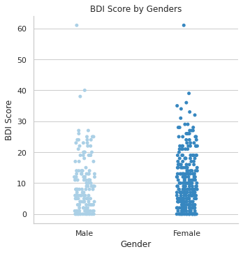

```python
sns.catplot(x = 'Gender', y = 'BDI Score',data = df,
            palette="Blues").set(title="BDI Score by Genders");
```

*We see that women have a higher average rate of marital depression than men.*

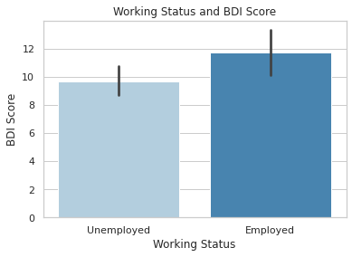

```python
sns.set_theme(style="whitegrid")
sns.barplot(x="Working Status", y="BDI Score", data=df,
            palette="Blues").set(title="Working Status and BDI Score");
```

*It is clear that unemployed people experience less marital depression than employed people.*

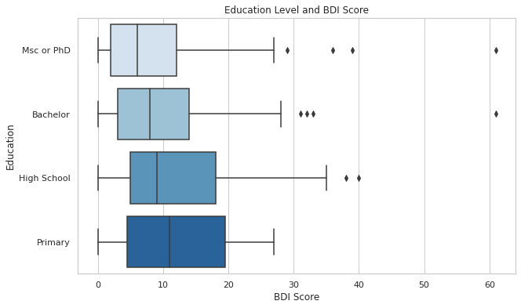

```python
plt.figure(figsize=(10,6))
bxp = sns.boxplot(y = 'Education', x = 'BDI Score',data = df,
                  palette="Blues").set(title="Education Level and BDI Score");
```

*Increasing people's level of education leads to psychologically healthier family life. In short, education brings peace.*

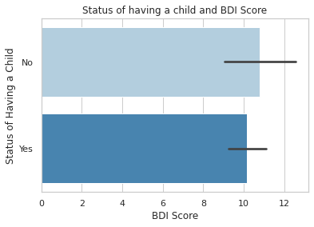

```python
sns.barplot(x="BDI Score", y="Status of Having a Child", data=df,
            palette="Blues").set(title="Status of having a child and BDI Score");
```

*Individuals in families with children experience less marital depression on average. We will examine this topic separately for genders in the future*

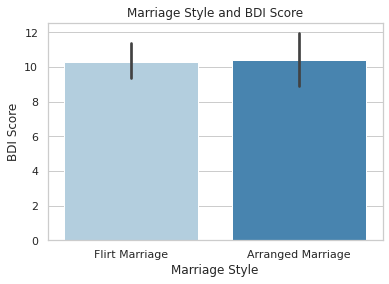

```python
sns.barplot(x = "Marriage Style", y = "BDI Score", data = df,
            palette = "Blues").set(title="Marriage Style and BDI Score");
```